# 45896968

## Portfolio Part 4 - Predicting Credit Card Approval

#### About the Dataset

Lending credit cards is a financial risk that financial institutions take. To control this risk, the institutions use personal information and data submitted by credit card applicants as well as their credit scores to predict the probability of any future defaults.

#### Task

Train classification models to predict whether a credit card application will be approved or denied based on various applicant characteristics and financial features.

#### Variable definitions in the Dataset

| Feature Name (application_record.csv) | Explanation |
| --- | --- |
| ID | Client Number |
| CODE_GENDER | Gender |
| FLAG_OWN_CAR | Is there a Car |
| FLAG_OWN_REALTY | Is there a Property |
| CNT_CHILDREN | Number of Children |
| AMT_INCOME_TOTAL | Annual Income |
| NAME_INCOME_TYPE | Income Category |
| NAME_EDUCATION_TYPE | Education Level |
| NAME_FAMILY_STATUS | Marital Status |
| NAME_HOUSING_TYPE | Way of Living |
| DAYS_BIRTH | Birthday |
| DAYS_EMPLOYED | Start date of Employment |
| FLAG_MOBIL | Is there a mobile phone |
| FLAG_WORK_PHONE | Is there a work phone |
| FLAG_PHONE | Is there a phone |
| FLAG_EMAIL | Is there an email |
| OCCUPATION_TYPE | Gaussian |
| CNT_FAM_MEMBERS | Family size |

| Feature Name (credit_record.csv) | Explanation |
| --- | --- |
| ID | Client Number |
| MONTHS_BALANCE | Record month |
| STATUS | Status |

#### Additional variable description

[output not shown]

Dataset available at : https://www.kaggle.com/datasets/rikdifos/credit-card-approval-prediction/data

```python
student_name = "Kate Lee"
student_id = "45896968"
```

#### Loading Libraries

```python
import pandas as pd
import numpy as np
from sklearn.preprocessing import OrdinalEncoder


import seaborn as sns
import seaborn as sb
import matplotlib.pylab as plt
import matplotlib.pyplot as plt
%matplotlib inline
```

#### Load Dataset

```python
df_application = pd.read_csv("application_record.csv")
df_application
```

|  | ID | CODE_GENDER | FLAG_OWN_CAR | FLAG_OWN_REALTY | CNT_CHILDREN | AMT_INCOME_TOTAL | NAME_INCOME_TYPE | NAME_EDUCATION_TYPE | NAME_FAMILY_STATUS | NAME_HOUSING_TYPE | DAYS_BIRTH | DAYS_EMPLOYED | FLAG_MOBIL | FLAG_WORK_PHONE | FLAG_PHONE | FLAG_EMAIL | OCCUPATION_TYPE | CNT_FAM_MEMBERS |
| --- | --- | --- | --- | --- | --- | --- | --- | --- | --- | --- | --- | --- | --- | --- | --- | --- | --- | --- |
| 0 | 5008804 | M | Y | Y | 0 | 427500.0 | Working | Higher education | Civil marriage | Rented apartment | -12005 | -4542 | 1 | 1 | 0 | 0 | NaN | 2 |
| 1 | 5008805 | M | Y | Y | 0 | 427500.0 | Working | Higher education | Civil marriage | Rented apartment | -12005 | -4542 | 1 | 1 | 0 | 0 | NaN | 2 |
| 2 | 5008806 | M | Y | Y | 0 | 112500.0 | Working | Secondary / secondary special | Married | House / apartment | -21474 | -1134 | 1 | 0 | 0 | 0 | Security staff | 2 |
| 3 | 5008808 | F | N | Y | 0 | 270000.0 | Commercial associate | Secondary / secondary special | Single / not married | House / apartment | -19110 | -3051 | 1 | 0 | 1 | 1 | Sales staff | 1 |
| 4 | 5008809 | F | N | Y | 0 | 270000.0 | Commercial associate | Secondary / secondary special | Single / not married | House / apartment | -19110 | -3051 | 1 | 0 | 1 | 1 | Sales staff | 1 |
| ... | ... | ... | ... | ... | ... | ... | ... | ... | ... | ... | ... | ... | ... | ... | ... | ... | ... | ... |
| 438552 | 6840104 | M | N | Y | 0 | 135000.0 | Pensioner | Secondary / secondary special | Separated | House / apartment | -22717 | 365243 | 1 | 0 | 0 | 0 | NaN | 1 |
| 438553 | 6840222 | F | N | N | 0 | 103500.0 | Working | Secondary / secondary special | Single / not married | House / apartment | -15939 | -3007 | 1 | 0 | 0 | 0 | Laborers | 1 |
| 438554 | 6841878 | F | N | N | 0 | 54000.0 | Commercial associate | Higher education | Single / not married | With parents | -8169 | -372 | 1 | 1 | 0 | 0 | Sales staff | 1 |
| 438555 | 6842765 | F | N | Y | 0 | 72000.0 | Pensioner | Secondary / secondary special | Married | House / apartment | -21673 | 365243 | 1 | 0 | 0 | 0 | NaN | 2 |
| 438556 | 6842885 | F | N | Y | 0 | 121500.0 | Working | Secondary / secondary special | Married | House / apartment | -18858 | -1201 | 1 | 0 | 1 | 0 | Sales staff | 2 |

438557 rows × 18 columns

```python
df_credit = pd.read_csv("credit_record.csv")
df_credit
```

|  | ID | MONTHS_BALANCE | STATUS |
| --- | --- | --- | --- |
| 0 | 5001711 | 0 | X |
| 1 | 5001711 | -1 | 0 |
| 2 | 5001711 | -2 | 0 |
| 3 | 5001711 | -3 | 0 |
| 4 | 5001712 | 0 | C |
| ... | ... | ... | ... |
| 1048570 | 5150487 | -25 | C |
| 1048571 | 5150487 | -26 | C |
| 1048572 | 5150487 | -27 | C |
| 1048573 | 5150487 | -28 | C |
| 1048574 | 5150487 | -29 | C |

1048575 rows × 3 columns

```python
df = pd.merge(df_application, df_credit, on='ID', how='inner')
df
```

|  | ID | CODE_GENDER | FLAG_OWN_CAR | FLAG_OWN_REALTY | CNT_CHILDREN | AMT_INCOME_TOTAL | NAME_INCOME_TYPE | NAME_EDUCATION_TYPE | NAME_FAMILY_STATUS | NAME_HOUSING_TYPE | DAYS_BIRTH | DAYS_EMPLOYED | FLAG_MOBIL | FLAG_WORK_PHONE | FLAG_PHONE | FLAG_EMAIL | OCCUPATION_TYPE | CNT_FAM_MEMBERS | MONTHS_BALANCE | STATUS |
| --- | --- | --- | --- | --- | --- | --- | --- | --- | --- | --- | --- | --- | --- | --- | --- | --- | --- | --- | --- | --- |
| 0 | 5008804 | M | Y | Y | 0 | 427500.0 | Working | Higher education | Civil marriage | Rented apartment | -12005 | -4542 | 1 | 1 | 0 | 0 | NaN | 2 | 0 | C |
| 1 | 5008804 | M | Y | Y | 0 | 427500.0 | Working | Higher education | Civil marriage | Rented apartment | -12005 | -4542 | 1 | 1 | 0 | 0 | NaN | 2 | -1 | C |
| 2 | 5008804 | M | Y | Y | 0 | 427500.0 | Working | Higher education | Civil marriage | Rented apartment | -12005 | -4542 | 1 | 1 | 0 | 0 | NaN | 2 | -2 | C |
| 3 | 5008804 | M | Y | Y | 0 | 427500.0 | Working | Higher education | Civil marriage | Rented apartment | -12005 | -4542 | 1 | 1 | 0 | 0 | NaN | 2 | -3 | C |
| 4 | 5008804 | M | Y | Y | 0 | 427500.0 | Working | Higher education | Civil marriage | Rented apartment | -12005 | -4542 | 1 | 1 | 0 | 0 | NaN | 2 | -4 | C |
| ... | ... | ... | ... | ... | ... | ... | ... | ... | ... | ... | ... | ... | ... | ... | ... | ... | ... | ... | ... | ... |
| 777710 | 5150337 | M | N | Y | 0 | 112500.0 | Working | Secondary / secondary special | Single / not married | Rented apartment | -9188 | -1193 | 1 | 0 | 0 | 0 | Laborers | 1 | -9 | 0 |
| 777711 | 5150337 | M | N | Y | 0 | 112500.0 | Working | Secondary / secondary special | Single / not married | Rented apartment | -9188 | -1193 | 1 | 0 | 0 | 0 | Laborers | 1 | -10 | 2 |
| 777712 | 5150337 | M | N | Y | 0 | 112500.0 | Working | Secondary / secondary special | Single / not married | Rented apartment | -9188 | -1193 | 1 | 0 | 0 | 0 | Laborers | 1 | -11 | 1 |
| 777713 | 5150337 | M | N | Y | 0 | 112500.0 | Working | Secondary / secondary special | Single / not married | Rented apartment | -9188 | -1193 | 1 | 0 | 0 | 0 | Laborers | 1 | -12 | 0 |
| 777714 | 5150337 | M | N | Y | 0 | 112500.0 | Working | Secondary / secondary special | Single / not married | Rented apartment | -9188 | -1193 | 1 | 0 | 0 | 0 | Laborers | 1 | -13 | 0 |

777715 rows × 20 columns

#### Initial Analysis on Dataset

```python
print('Shape of Application Record:', df_application.shape)
print('Shape of Credit Record:', df_credit.shape)
print('Shape of Merged dataset:', df.shape)
```

```
Shape of Application Record: (438557, 18)
Shape of Credit Record: (1048575, 3)
Shape of Merged dataset: (777715, 20)
```

```python
df.info()
```

```
<class 'pandas.core.frame.DataFrame'>
RangeIndex: 777715 entries, 0 to 777714
Data columns (total 20 columns):
 #   Column               Non-Null Count   Dtype
---  ------               --------------   -----
 0   ID                   777715 non-null  int64
 1   CODE_GENDER          777715 non-null  object
 2   FLAG_OWN_CAR         777715 non-null  object
 3   FLAG_OWN_REALTY      777715 non-null  object
 4   CNT_CHILDREN         777715 non-null  int64
 5   AMT_INCOME_TOTAL     777715 non-null  float64
 6   NAME_INCOME_TYPE     777715 non-null  object
 7   NAME_EDUCATION_TYPE  777715 non-null  object
 8   NAME_FAMILY_STATUS   777715 non-null  object
 9   NAME_HOUSING_TYPE    777715 non-null  object
 10  DAYS_BIRTH           777715 non-null  int64
 11  DAYS_EMPLOYED        777715 non-null  int64
 12  FLAG_MOBIL           777715 non-null  int64
 13  FLAG_WORK_PHONE      777715 non-null  int64
 14  FLAG_PHONE           777715 non-null  int64
 15  FLAG_EMAIL           777715 non-null  int64
 16  OCCUPATION_TYPE      537667 non-null  object
 17  CNT_FAM_MEMBERS      777715 non-null  int64
 18  MONTHS_BALANCE       777715 non-null  int64
 19  STATUS               777715 non-null  object
dtypes: float64(1), int64(10), object(9)
memory usage: 118.7+ MB
```

#### Analysis Outputs

- The Dataset consists of 777,715 rows and 20 columns
- The types of variables in the dataset are in numerical format (Integer or Float) and categoical (object).

#### Preparing for Exploratory Data Analysis

```python
df.isnull().sum()
```

```
ID                          0
CODE_GENDER                 0
FLAG_OWN_CAR                0
FLAG_OWN_REALTY             0
CNT_CHILDREN                0
AMT_INCOME_TOTAL            0
NAME_INCOME_TYPE            0
NAME_EDUCATION_TYPE         0
NAME_FAMILY_STATUS          0
NAME_HOUSING_TYPE           0
DAYS_BIRTH                  0
DAYS_EMPLOYED               0
FLAG_MOBIL                  0
FLAG_WORK_PHONE             0
FLAG_PHONE                  0
FLAG_EMAIL                  0
OCCUPATION_TYPE        240048
CNT_FAM_MEMBERS             0
MONTHS_BALANCE              0
STATUS                      0
dtype: int64
```

```python
df.dropna(inplace=True)
```

```python
df.isnull().sum()
```

```
ID                     0
CODE_GENDER            0
FLAG_OWN_CAR           0
FLAG_OWN_REALTY        0
CNT_CHILDREN           0
AMT_INCOME_TOTAL       0
NAME_INCOME_TYPE       0
NAME_EDUCATION_TYPE    0
NAME_FAMILY_STATUS     0
NAME_HOUSING_TYPE      0
DAYS_BIRTH             0
DAYS_EMPLOYED          0
FLAG_MOBIL             0
FLAG_WORK_PHONE        0
FLAG_PHONE             0
FLAG_EMAIL             0
OCCUPATION_TYPE        0
CNT_FAM_MEMBERS        0
MONTHS_BALANCE         0
STATUS                 0
dtype: int64
```

```python
unique_number = []
for i in df.columns:
    x = df[i].value_counts().count()
    unique_number.append(x)

pd.DataFrame(unique_number, index=df.columns, columns= ["Total Unique Values"])
```

|  | Total Unique Values |
| --- | --- |
| ID | 25134 |
| CODE_GENDER | 2 |
| FLAG_OWN_CAR | 2 |
| FLAG_OWN_REALTY | 2 |
| CNT_CHILDREN | 9 |
| AMT_INCOME_TOTAL | 195 |
| NAME_INCOME_TYPE | 5 |
| NAME_EDUCATION_TYPE | 5 |
| NAME_FAMILY_STATUS | 5 |
| NAME_HOUSING_TYPE | 6 |
| DAYS_BIRTH | 5206 |
| DAYS_EMPLOYED | 3299 |
| FLAG_MOBIL | 1 |
| FLAG_WORK_PHONE | 2 |
| FLAG_PHONE | 2 |
| FLAG_EMAIL | 2 |
| OCCUPATION_TYPE | 18 |
| CNT_FAM_MEMBERS | 10 |
| MONTHS_BALANCE | 61 |
| STATUS | 8 |

According to the dataset:

- There are:
  - 9 unique values in "CNT_CHILDREN"
  - 5 unique values in "NAME_INCOME_TYPE"
  - 5 unique values in "NAME_EDUCATION_TYPE"
  - 5 unique values in "NAME_FAMILY_STATUS"
  - 6 unique values in "NAME_HOUSING_TYPE"
  - 18 unique values in "OCCUPATION_TYPE"
  - 10 unique values in "CNT_FAM_MEMBERS"
  - 8 unique values in "STATUS"
- Numeric Variable = "CNT_CHILDREN", "AMT_INCOME_TOTAL", "DAYS_BIRTH", "DAYS_EMPLOYED", "FLAG_MOBIL", "FLAG_WORK_PHONE", "FLAG_PHONE", "FLAG_EMAIL", "FLAG_EMAIL", "MONTHS_BALANCE"
- Categorical Variables = "CODE_GENDER", "FLAG_OWN_CAR", "FLAG_OWN_CAR", "NAME_INCOME_TYPE", "NAME_EDUCATION_TYPE", "NAME_FAMILY_STATUS", "NAME_HOUSING_TYPE", "OCCUPATION_TYPE", "STATUS"

## Exploratory Data Analysis

#### Uni-variate Analysis

```python
df.describe()
```

|  | ID | CNT_CHILDREN | AMT_INCOME_TOTAL | DAYS_BIRTH | DAYS_EMPLOYED | FLAG_MOBIL | FLAG_WORK_PHONE | FLAG_PHONE | FLAG_EMAIL | CNT_FAM_MEMBERS | MONTHS_BALANCE |
| --- | --- | --- | --- | --- | --- | --- | --- | --- | --- | --- | --- |
| count | 5.376670e+05 | 537667.000000 | 5.376670e+05 | 537667.000000 | 537667.000000 | 537667.0 | 537667.000000 | 537667.000000 | 537667.000000 | 537667.000000 | 537667.000000 |
| mean | 5.079231e+06 | 0.506697 | 1.971171e+05 | -15010.958999 | -2762.029935 | 1.0 | 0.281615 | 0.298893 | 0.100730 | 2.303069 | -19.305241 |
| std | 4.200200e+04 | 0.787285 | 1.041390e+05 | 3416.418092 | 2393.919456 | 0.0 | 0.449787 | 0.457773 | 0.300971 | 0.936852 | 14.037827 |
| min | 5.008806e+06 | 0.000000 | 2.700000e+04 | -24611.000000 | -15713.000000 | 1.0 | 0.000000 | 0.000000 | 0.000000 | 1.000000 | -60.000000 |
| 25% | 5.044925e+06 | 0.000000 | 1.350000e+05 | -17594.000000 | -3661.000000 | 1.0 | 0.000000 | 0.000000 | 0.000000 | 2.000000 | -29.000000 |
| 50% | 5.079091e+06 | 0.000000 | 1.800000e+05 | -14785.000000 | -2147.000000 | 1.0 | 0.000000 | 0.000000 | 0.000000 | 2.000000 | -17.000000 |
| 75% | 5.115755e+06 | 1.000000 | 2.295000e+05 | -12239.000000 | -1050.000000 | 1.0 | 1.000000 | 1.000000 | 0.000000 | 3.000000 | -8.000000 |
| max | 5.150487e+06 | 19.000000 | 1.575000e+06 | -7489.000000 | -17.000000 | 1.0 | 1.000000 | 1.000000 | 1.000000 | 20.000000 | 0.000000 |

```python
df["CNT_CHILDREN"].value_counts()
```

```
CNT_CHILDREN
0     343151
1     127695
2      58791
3       6549
4       1070
5        248
14       111
7         46
19         6
Name: count, dtype: int64
```

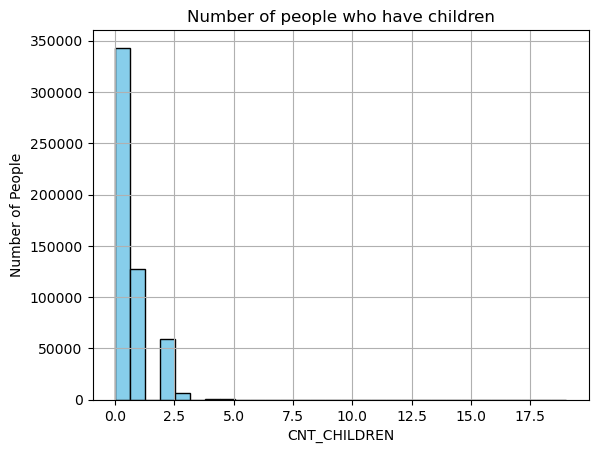

```python
plt.hist(df['CNT_CHILDREN'], bins=30, color='skyblue', edgecolor='black')

plt.xlabel('CNT_CHILDREN')
plt.ylabel('Number of People')
plt.title('Number of people who have children')
plt.grid(True)

plt.show()
```

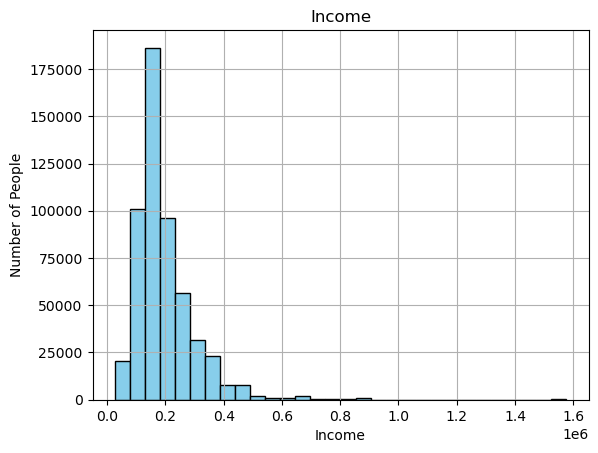

```python
plt.hist(df['AMT_INCOME_TOTAL'], bins=30, color='skyblue', edgecolor='black')

plt.xlabel('Income')
plt.ylabel('Number of People')
plt.title('Income')
plt.grid(True)

plt.show()
```

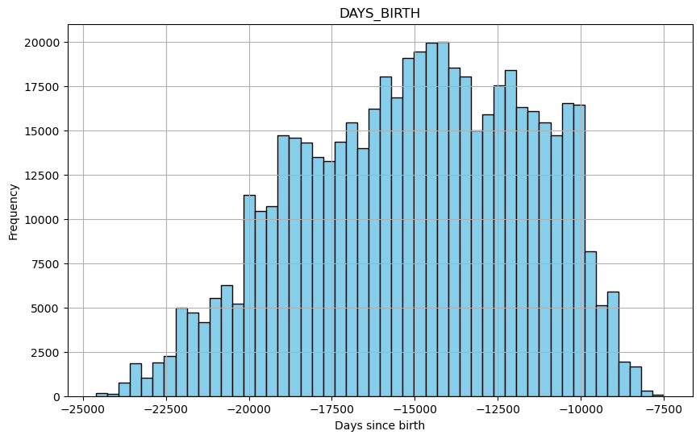

```python
plt.figure(figsize=(10, 6))
plt.hist(df['DAYS_BIRTH'], bins=50, color='skyblue', edgecolor='black')

plt.xlabel('Days since birth')
plt.ylabel('Frequency')
plt.title('DAYS_BIRTH')
plt.grid(True)

plt.show()
```

```python
from datetime import datetime
```

```python
df['DAYS_BIRTH'] = datetime.strptime("2024-01-01", "%Y-%m-%d") + df['DAYS_BIRTH'].apply(pd.offsets.Day)
```

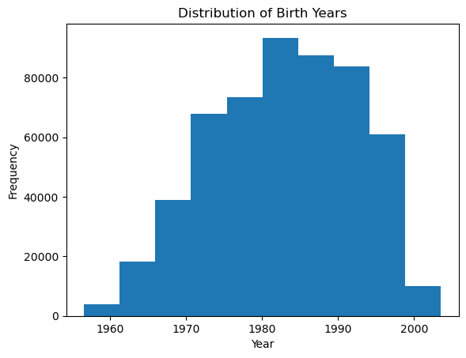

```python
plt.hist(df['DAYS_BIRTH'])
plt.xlabel('Year')
plt.ylabel('Frequency')
plt.title('Distribution of Birth Years')
plt.show()
```

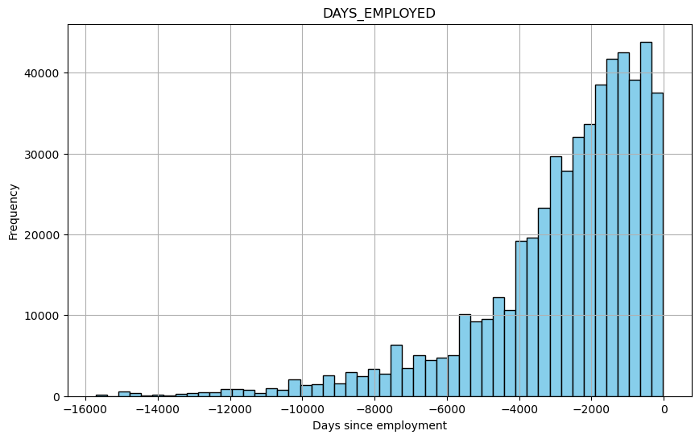

```python
plt.figure(figsize=(10, 6))
plt.hist(df['DAYS_EMPLOYED'], bins=50, color='skyblue', edgecolor='black')

plt.xlabel('Days since employment')
plt.ylabel('Frequency')
plt.title('DAYS_EMPLOYED')
plt.grid(True)

plt.show()
```

```python
df['DAYS_EMPLOYED'] = datetime.strptime("2024-01-01", "%Y-%m-%d") + df['DAYS_EMPLOYED'].apply(pd.offsets.Day)
```

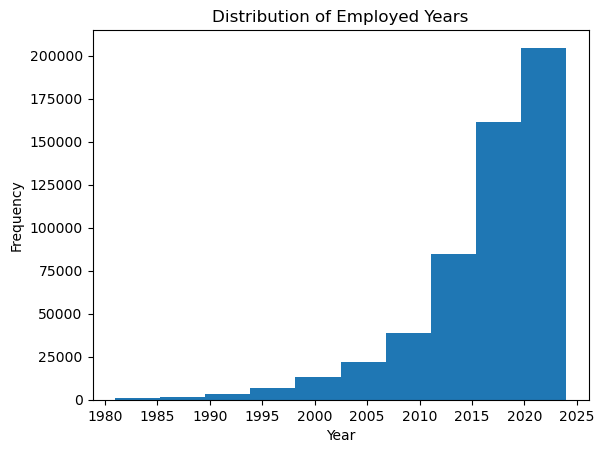

```python
plt.hist(df['DAYS_EMPLOYED'])
plt.xlabel('Year')
plt.ylabel('Frequency')
plt.title('Distribution of Employed Years')
plt.show()
```

```python
df["CNT_FAM_MEMBERS"].value_counts()
```

```
CNT_FAM_MEMBERS
2     279187
3     109948
1      84957
4      55637
5       6536
6        991
7        248
15       111
9         46
20         6
Name: count, dtype: int64
```

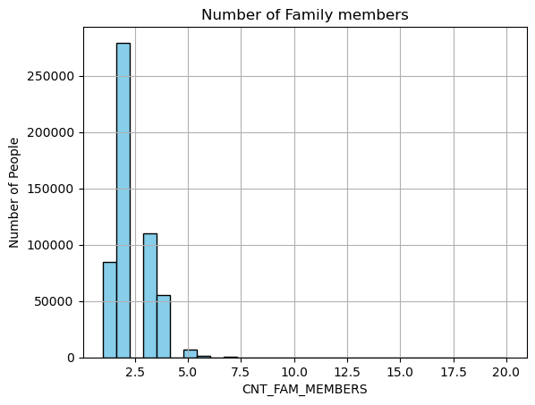

```python
plt.hist(df['CNT_FAM_MEMBERS'], bins=30, color='skyblue', edgecolor='black')

plt.xlabel('CNT_FAM_MEMBERS')
plt.ylabel('Number of People')
plt.title('Number of Family members')
plt.grid(True)

plt.show()
```

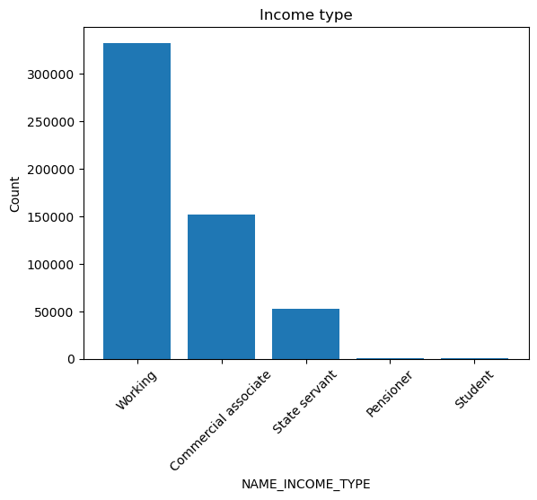

```python
plt.bar(df["NAME_INCOME_TYPE"].value_counts().index, df["NAME_INCOME_TYPE"].value_counts().values)

plt.xlabel("NAME_INCOME_TYPE")
plt.ylabel("Count")
plt.title("Income type")
plt.xticks(rotation=45)

plt.show()
```

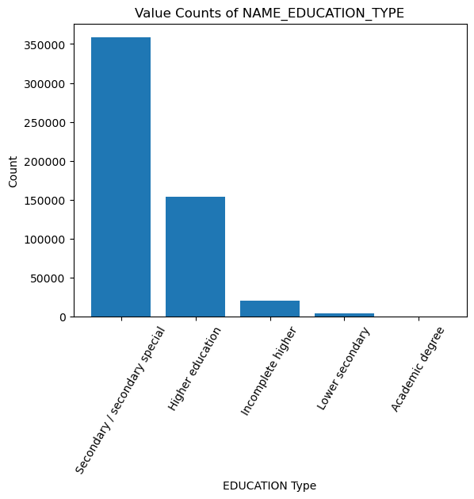

```python
plt.bar(df["NAME_EDUCATION_TYPE"].value_counts().index, df["NAME_EDUCATION_TYPE"].value_counts().values)

plt.xlabel("EDUCATION Type")
plt.ylabel("Count")
plt.title("Value Counts of NAME_EDUCATION_TYPE")
plt.xticks(rotation=60)

plt.show()
```

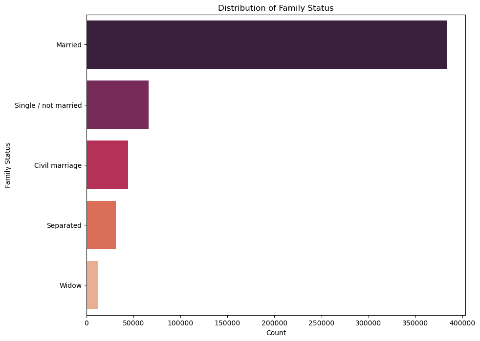

```python
family_status_counts = df["NAME_FAMILY_STATUS"].value_counts()

plt.figure(figsize=(10, 8))
sns.barplot(x=family_status_counts.values, y=family_status_counts.index, palette='rocket')

plt.xlabel('Count')
plt.ylabel('Family Status')
plt.title('Distribution of Family Status')

plt.show()
```

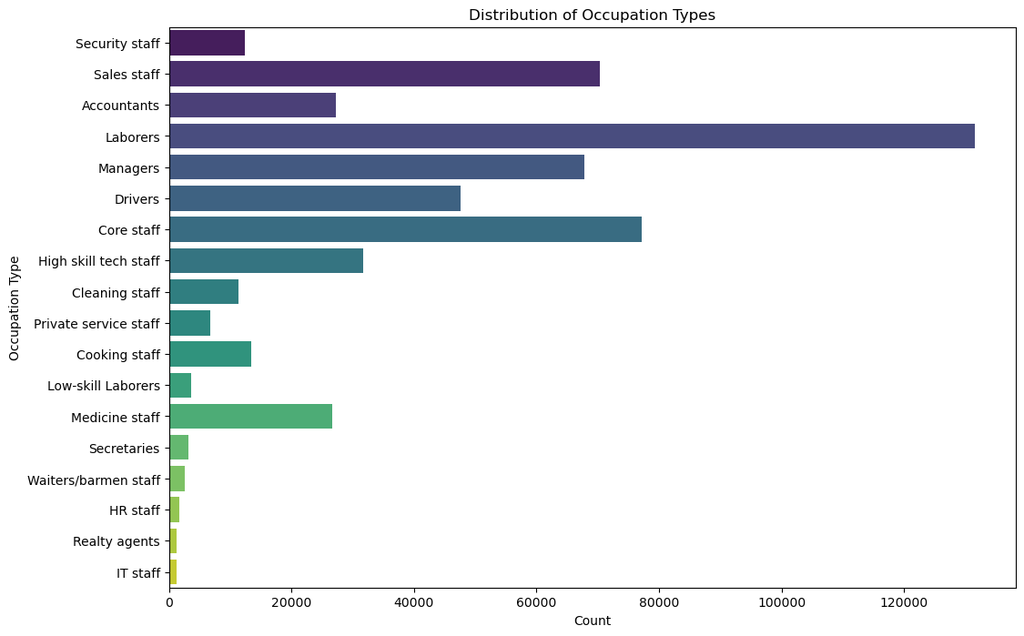

```python
plt.figure(figsize=(12, 8))
sns.countplot(y='OCCUPATION_TYPE', data=df, palette='viridis')

plt.xlabel('Count')
plt.ylabel('Occupation Type')
plt.title('Distribution of Occupation Types')

plt.show()
```

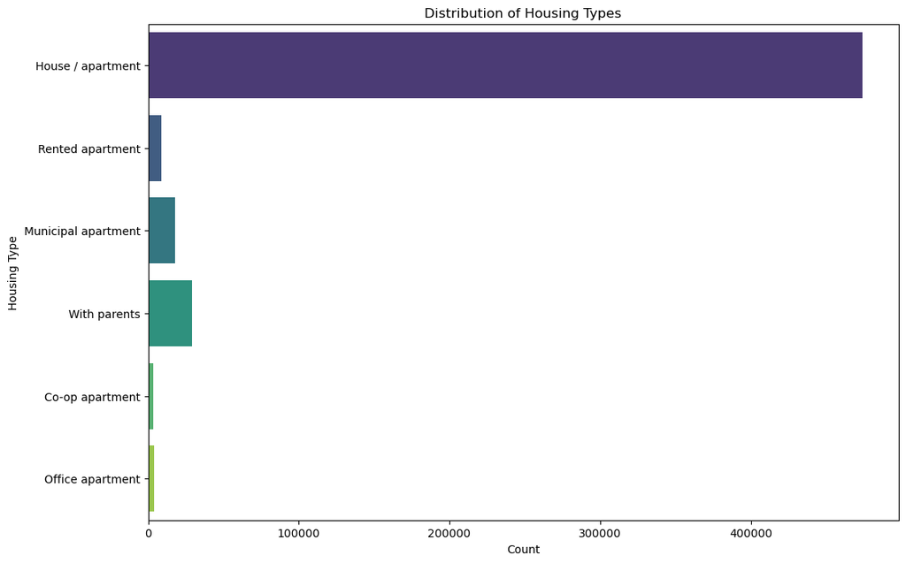

```python
plt.figure(figsize=(12, 8))
sns.countplot(y='NAME_HOUSING_TYPE', data=df, palette='viridis')

plt.xlabel('Count')
plt.ylabel('Housing Type')
plt.title('Distribution of Housing Types')

plt.show()
```

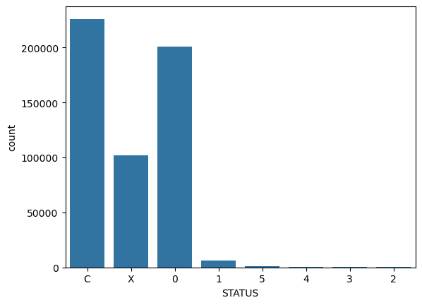

```python
sns.countplot (x='STATUS',data=df)
```

```python
df["MONTHS_BALANCE"]=df["MONTHS_BALANCE"]*-1
```

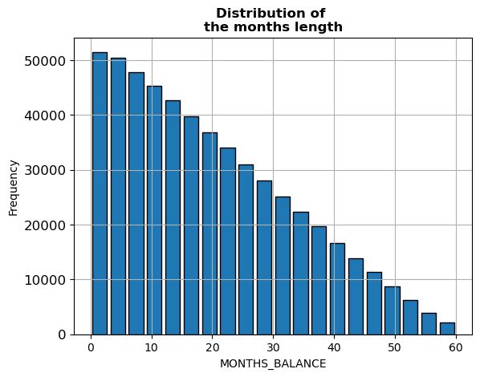

```python
ax = df["MONTHS_BALANCE"].hist(xlabelsize=10, ylabelsize=12, bins=20, edgecolor='black',rwidth=0.8)

ax.set_title('Distribution of \nthe months length',weight='bold')

ax.set_xlabel('MONTHS_BALANCE')
ax.set_ylabel('Frequency')

plt.show()
```

#### Analysis Output

According to the visualisations and the statistic descriptions:

- Majority of the applicants do not have children (343,151 total people).
- Most applicants are born between 1980 and 1990 with the least applicants born in 1960s and 2000s.
- There is a slow increase throughout the years of those who started working.
- Most applicants are currently working with the least applicants being students.
- Most occupation type is a labourer with the least being IT staff.
- Most applicants are married.
- Most applicants are living in a house/apartment
- Most applicants have a good credit score status

#### Bi-variate Analysis

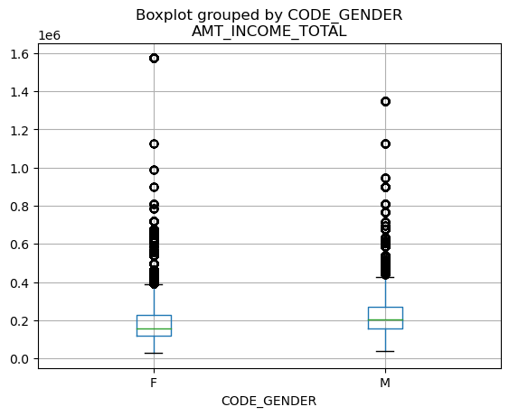

```python
df.boxplot("AMT_INCOME_TOTAL", by = "CODE_GENDER")
```

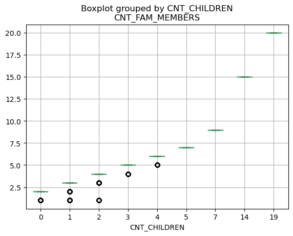

```python
df.boxplot("CNT_FAM_MEMBERS", by = "CNT_CHILDREN")
```

```python
# Converting categorical features into numerical values
encoder = OrdinalEncoder()
df[['CODE_GENDER', 'FLAG_OWN_CAR', 'FLAG_OWN_REALTY','NAME_INCOME_TYPE','NAME_EDUCATION_TYPE','NAME_FAMILY_STATUS','NAME_HOUSING_TYPE','OCCUPATION_TYPE','STATUS','DAYS_EMPLOYED','DAYS_BIRTH']] = encoder.fit_transform(df[['CODE_GENDER', 'FLAG_OWN_CAR', 'FLAG_OWN_REALTY','NAME_INCOME_TYPE','NAME_EDUCATION_TYPE','NAME_FAMILY_STATUS','NAME_HOUSING_TYPE','OCCUPATION_TYPE','STATUS','DAYS_EMPLOYED','DAYS_BIRTH']])
```

```python
corr_matrix = df.corr()
print("Correlation matrix:")
print(corr_matrix)
```

```
Correlation matrix:
                           ID  CODE_GENDER  FLAG_OWN_CAR  FLAG_OWN_REALTY  \
ID                   1.000000    -0.004041     -0.025431        -0.085132
CODE_GENDER         -0.004041     1.000000      0.346480        -0.043079
FLAG_OWN_CAR        -0.025431     0.346480      1.000000         0.005176
FLAG_OWN_REALTY     -0.085132    -0.043079      0.005176         1.000000
CNT_CHILDREN         0.031586     0.046246      0.072250         0.007409
AMT_INCOME_TOTAL    -0.024915     0.191443      0.201243         0.043247
NAME_INCOME_TYPE     0.025639     0.046306     -0.001487        -0.036081
NAME_EDUCATION_TYPE -0.001710     0.044808     -0.075241         0.002595
NAME_FAMILY_STATUS   0.006340    -0.067353     -0.094533         0.016231
NAME_HOUSING_TYPE    0.009560     0.047621      0.001701        -0.174455
DAYS_BIRTH           0.029162     0.113032      0.079651        -0.094894
DAYS_EMPLOYED        0.013607     0.113329      0.035701        -0.016790
FLAG_MOBIL                NaN          NaN           NaN              NaN
FLAG_WORK_PHONE      0.098981     0.015376     -0.027221        -0.216011
FLAG_PHONE           0.014584    -0.026068     -0.032976        -0.059563
FLAG_EMAIL          -0.072886    -0.022866      0.005493         0.060949
OCCUPATION_TYPE      0.013623    -0.014048     -0.040148         0.015576
CNT_FAM_MEMBERS      0.026159     0.075483      0.114709         0.007272
MONTHS_BALANCE      -0.004673    -0.013313      0.000517         0.005988
STATUS               0.012956     0.005642      0.004990        -0.004834

                     CNT_CHILDREN  AMT_INCOME_TOTAL  NAME_INCOME_TYPE  \
ID                       0.031586         -0.024915          0.025639
CODE_GENDER              0.046246          0.191443          0.046306
FLAG_OWN_CAR             0.072250          0.201243         -0.001487
FLAG_OWN_REALTY          0.007409          0.043247         -0.036081
CNT_CHILDREN             1.000000         -0.014309          0.034045
AMT_INCOME_TOTAL        -0.014309          1.000000         -0.156425
NAME_INCOME_TYPE         0.034045         -0.156425          1.000000
NAME_EDUCATION_TYPE     -0.031554         -0.220444          0.121248
NAME_FAMILY_STATUS      -0.143813          0.031923         -0.010589
NAME_HOUSING_TYPE        0.020314         -0.016504          0.001489
DAYS_BIRTH               0.273708         -0.047763         -0.016915
DAYS_EMPLOYED            0.040363         -0.034838         -0.029040
FLAG_MOBIL                    NaN               NaN               NaN
FLAG_WORK_PHONE         -0.016432         -0.078836          0.072173
FLAG_PHONE              -0.029202          0.007914          0.006629
FLAG_EMAIL              -0.013942          0.067699         -0.029954
```

[output cut: 77 more lines]

```
AMT_INCOME_TOTAL           -0.025477        0.001829 -0.015165
NAME_INCOME_TYPE            0.036957        0.004922  0.010963
NAME_EDUCATION_TYPE        -0.019661        0.001658 -0.016153
NAME_FAMILY_STATUS         -0.503980       -0.018498 -0.014786
NAME_HOUSING_TYPE          -0.002647       -0.015019  0.002312
DAYS_BIRTH                  0.233141       -0.051892  0.010919
DAYS_EMPLOYED               0.020640       -0.050097 -0.011506
FLAG_MOBIL                       NaN             NaN       NaN
FLAG_WORK_PHONE             0.001964        0.002339  0.014113
FLAG_PHONE                 -0.015966        0.007564  0.002273
FLAG_EMAIL                 -0.012525       -0.005860 -0.015594
OCCUPATION_TYPE            -0.010688       -0.007986 -0.010360
CNT_FAM_MEMBERS             1.000000        0.008847  0.002133
MONTHS_BALANCE              0.008847        1.000000 -0.138573
STATUS                      0.002133       -0.138573  1.000000
```

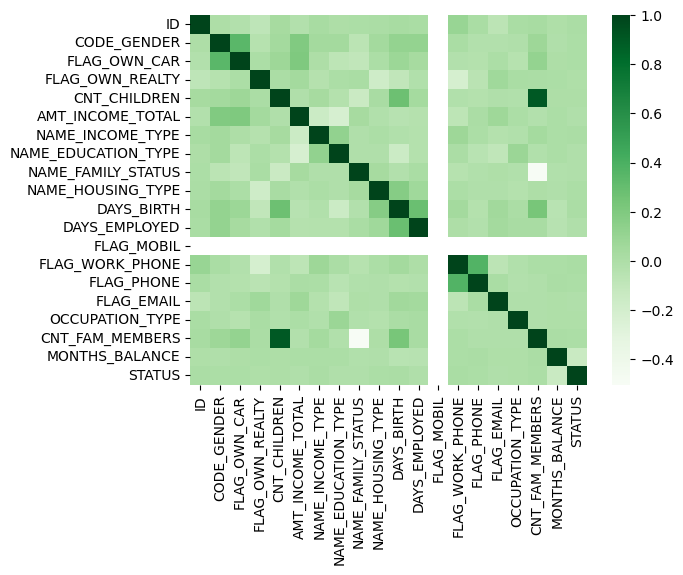

```python
sns.heatmap(corr_matrix, cmap="Greens")
```

```python
df=df.drop(["FLAG_PHONE"], axis=1)
```

#### Analysis Output

According to the dataset:

- There is a high correlation between "CNT_CHILDREN" and "CNT_FAMILY_MEMBERS" of 0.9 which suggests that those who have more children has more family members and vice versa.

#### Split Training and Testing Data

```python
from sklearn.model_selection import train_test_split
from sklearn import metrics
```

```python
X = df.drop(["ID",'STATUS'], axis=1)
y = df['STATUS']
```

```python
# Split the data into training and testing sets (70% training, 30% testing)
X_train, X_test, y_train, y_test = train_test_split(X, y, test_size=0.3, random_state=42)

# Print the shapes of the training and testing sets to verify the split
print("Training data shape (X, y):", X_train.shape, y_train.shape)
print("Testing data shape (X, y):", X_test.shape, y_test.shape)
```

```
Training data shape (X, y): (376366, 17) (376366,)
Testing data shape (X, y): (161301, 17) (161301,)
```

#### Training a Logistic Regression Model

```python
from sklearn.linear_model import LogisticRegression
from sklearn.metrics import accuracy_score
from sklearn.preprocessing import StandardScaler
from sklearn.metrics import accuracy_score, f1_score, roc_auc_score
from sklearn.ensemble import RandomForestClassifier
```

```python
scaler = StandardScaler()

X_train_scaled = scaler.fit_transform(X_train)
X_test_scaled = scaler.transform(X_test)
```

```python
# Initialize the logistic regression model
logreg = LogisticRegression()
```

```python
# Train the model on the training data using selected features
logreg.fit(X_train, y_train)
```

```
LogisticRegression()
```

```python
# Predict the target variable on the training set
y_train_pred = logreg.predict(X_train)

# Predict the target variable on the test set
y_test_pred = logreg.predict(X_test)
```

#### Calculating the evaluation metrics

```python
train_accuracy = accuracy_score(y_train, y_train_pred)

test_accuracy = accuracy_score(y_test, y_test_pred)

print("Accuracy on training set:", train_accuracy)
print("Accuracy on test set:", test_accuracy)
```

```
Accuracy on training set: 0.42013625035205093
Accuracy on test set: 0.4219440673027446
```

```python
# Calculate F1-score
train_f1 = f1_score(y_train, y_train_pred, average='weighted')
test_f1 = f1_score(y_test, y_test_pred, average='weighted')

print("Training F1-score:", train_f1)
print("Testing F1-score:", test_f1)
```

```
Training F1-score: 0.24858807570910663
Testing F1-score: 0.25041321951530376
```

#### Explanation of the model and evaluation

The accuracy on both the training and test set indicates that model is not performing well.